# Assignment E

Multicollinearity; Qualitative & Quantitative predictors

## Instructions

1. You may talk to a friend, discuss the questions and potential directions for solving them. However, you need to write your own solutions and code separately, and not as a group activity.
2. Make R code chunks to insert code and type your answer outside the code chunks. Ensure that the solution is written neatly enough to understand and grade.
3. Render the file as HTML to submit. For theoretical questions, you can either type the answer and include the solutions in this file, or write the solution on paper, scan and submit separately.
4. The assignment is worth 100 points, and is due on **12th November 2023 at 11:59 pm**.
5. **Five points are properly formatting the assignment**. The breakdown is as follows:
- Must be an HTML file rendered using Quarto (the theory part may be scanned and submitted separately) (2 pts).
- There aren’t excessively long outputs of extraneous information (e.g. no printouts of entire data frames without good reason, there aren’t long printouts of which iteration a loop is on, there aren’t long sections of commented-out code, etc.). There is no piece of unnecessary / redundant code, and no unnecessary / redundant text (1 pt)
- Final answers of each question are written clearly (1 pt).
- The proofs are legible, and clearly written with reasoning provided for every step. They are easy to follow and understand (1 pt)

## Prostate

A study was conducted on 97 men with prostate cancer who were due to receive a radical prostatectomy. The dataset *prostate.csv* contains data on 9 measurements made on these 97 men. The description of variables can be found [here](https://rafalab.github.io/pages/649/prostate.html).

### Fitting the model

Fit a linear regression model with `lpsa` as the response and the other variables as the predictors. Write down the equation to predict `lpsa` based on the other eight variables. When coding the model in R, do not type the names of all the predictors.

*(2 points)*

```r
library(ggplot2)
prostate_data <- read.csv('prostate.csv')
lpsa_model <- lm(lpsa~ ., data=prostate_data)
summary(lpsa_model)
```

```
Call:
lm(formula = lpsa ~ ., data = prostate_data)

Residuals:
    Min      1Q  Median      3Q     Max
-1.7331 -0.3713 -0.0170  0.4141  1.6381

Coefficients:
             Estimate Std. Error t value Pr(>|t|)
(Intercept)  0.669337   1.296387   0.516  0.60693
lcavol       0.587022   0.087920   6.677 2.11e-09 ***
lweight      0.454467   0.170012   2.673  0.00896 **
age         -0.019637   0.011173  -1.758  0.08229 .
lbph         0.107054   0.058449   1.832  0.07040 .
svi          0.766157   0.244309   3.136  0.00233 **
lcp         -0.105474   0.091013  -1.159  0.24964
gleason      0.045142   0.157465   0.287  0.77503
pgg45        0.004525   0.004421   1.024  0.30886
---
Signif. codes:  0 '***' 0.001 '**' 0.01 '*' 0.05 '.' 0.1 ' ' 1

Residual standard error: 0.7084 on 88 degrees of freedom
Multiple R-squared:  0.6548,    Adjusted R-squared:  0.6234
F-statistic: 20.86 on 8 and 88 DF,  p-value: < 2.2e-16
```

### Model significance

Is the overall regression significant at 5% level? Justify your answer.

*(2 points)*

```r
summary(lpsa_model)
```

```
Call:
lm(formula = lpsa ~ ., data = prostate_data)

Residuals:
    Min      1Q  Median      3Q     Max
-1.7331 -0.3713 -0.0170  0.4141  1.6381

Coefficients:
             Estimate Std. Error t value Pr(>|t|)
(Intercept)  0.669337   1.296387   0.516  0.60693
lcavol       0.587022   0.087920   6.677 2.11e-09 ***
lweight      0.454467   0.170012   2.673  0.00896 **
age         -0.019637   0.011173  -1.758  0.08229 .
lbph         0.107054   0.058449   1.832  0.07040 .
svi          0.766157   0.244309   3.136  0.00233 **
lcp         -0.105474   0.091013  -1.159  0.24964
gleason      0.045142   0.157465   0.287  0.77503
pgg45        0.004525   0.004421   1.024  0.30886
---
Signif. codes:  0 '***' 0.001 '**' 0.01 '*' 0.05 '.' 0.1 ' ' 1

Residual standard error: 0.7084 on 88 degrees of freedom
Multiple R-squared:  0.6548,    Adjusted R-squared:  0.6234
F-statistic: 20.86 on 8 and 88 DF,  p-value: < 2.2e-16
```

Yes. The p-value associated with the F-statistic is 2.2e-16, which is less than 0.05, allowing us to reject the null hypothesis that none of the variables are associated with the response

### Interpretation

Interpret the coefficient of `svi`.

*(3 points)*

For every one unit increase in seminal vesicle invasion, lpsa is expected to increase by 0.7662 units, assuming all other predictors are held constant.

### Effect of other predictors

Fit a simple linear regression on `lpsa` against `gleason`. Is the predictor `gleason` statistically significant in this model?

Was `gleason` statistically significant in the model developed in the first question ([E.1.1](https://nustat.github.io/STAT350-class-notes/Assignment%20E.html#fitting-the-model)) with multiple predictors?

Did the statistical significance of `gleason` change in the absence of other predictors? Why or why not?

*(1 + 1 + 1 + 2 = 5 points)*

```r
lpsa_gleason <- lm(lpsa~gleason, data=prostate_data)
summary(lpsa_gleason)
```

```
Call:
lm(formula = lpsa ~ gleason, data = prostate_data)

Residuals:
     Min       1Q   Median       3Q      Max
-2.78684 -0.76755 -0.01295  0.71323  2.95861

Coefficients:
            Estimate Std. Error t value Pr(>|t|)
(Intercept)  -1.5044     1.0351  -1.453   0.1494
gleason       0.5898     0.1524   3.869   0.0002 ***
---
Signif. codes:  0 '***' 0.001 '**' 0.01 '*' 0.05 '.' 0.1 ' ' 1

Residual standard error: 1.079 on 95 degrees of freedom
Multiple R-squared:  0.1362,    Adjusted R-squared:  0.1271
F-statistic: 14.97 on 1 and 95 DF,  p-value: 0.0001999
```

In this model, gleason’s p-value (0.0002) suggests the predictor is statistically significant. However, in the MLR model, gleason is shown to be insignificant (p-value of 0.775). This occurs because the statistical significance of a predictor is not restricted to it’s relationship with the response, but with the other predictors as well. For example, in the MLR some of the other predictors might be accounting for the changes in the data that the SLR previously attributed to `gleason`; therefore, `gleason` isn’t a necessary predictor when other, more influential predictors are present, even though it seems to be significant when it is examined in a SLR.

### Relevant subset of predictors

Find the largest subset of predictors in the model developed in the first question ([E.1.1](https://nustat.github.io/STAT350-class-notes/Assignment%20E.html#fitting-the-model)), such that their coefficients are zero, i.e., none of the predictors in the subset are statistically significant. Assume a significance level of 5%.

Does the model $R^2_{adj}$ change a lot if you remove the set of predictors identified above from the model in the first question? Why or why not?

*(4 + 2 = 6 points)*

```r
#manual iteration through the predictors was done to find this subset of preds
significant_preds <- lm(lpsa~lcavol+svi+lweight, data=prostate_data)
summary(significant_preds)
```

```
Call:
lm(formula = lpsa ~ lcavol + svi + lweight, data = prostate_data)

Residuals:
     Min       1Q   Median       3Q      Max
-1.72964 -0.45764  0.02812  0.46403  1.57013

Coefficients:
            Estimate Std. Error t value Pr(>|t|)
(Intercept) -0.26809    0.54350  -0.493  0.62298
lcavol       0.55164    0.07467   7.388  6.3e-11 ***
svi          0.66616    0.20978   3.176  0.00203 **
lweight      0.50854    0.15017   3.386  0.00104 **
---
Signif. codes:  0 '***' 0.001 '**' 0.01 '*' 0.05 '.' 0.1 ' ' 1

Residual standard error: 0.7168 on 93 degrees of freedom
Multiple R-squared:  0.6264,    Adjusted R-squared:  0.6144
F-statistic: 51.99 on 3 and 93 DF,  p-value: < 2.2e-16
```

```r
summary(lpsa_model)
```

```
Call:
lm(formula = lpsa ~ ., data = prostate_data)

Residuals:
    Min      1Q  Median      3Q     Max
-1.7331 -0.3713 -0.0170  0.4141  1.6381

Coefficients:
             Estimate Std. Error t value Pr(>|t|)
(Intercept)  0.669337   1.296387   0.516  0.60693
lcavol       0.587022   0.087920   6.677 2.11e-09 ***
lweight      0.454467   0.170012   2.673  0.00896 **
age         -0.019637   0.011173  -1.758  0.08229 .
lbph         0.107054   0.058449   1.832  0.07040 .
svi          0.766157   0.244309   3.136  0.00233 **
lcp         -0.105474   0.091013  -1.159  0.24964
gleason      0.045142   0.157465   0.287  0.77503
pgg45        0.004525   0.004421   1.024  0.30886
---
Signif. codes:  0 '***' 0.001 '**' 0.01 '*' 0.05 '.' 0.1 ' ' 1

Residual standard error: 0.7084 on 88 degrees of freedom
Multiple R-squared:  0.6548,    Adjusted R-squared:  0.6234
F-statistic: 20.86 on 8 and 88 DF,  p-value: < 2.2e-16
```

By examining the model summary of the model from question 1, we can see that the subset of age, lbph, lcp, gleason, and pgg45 are all statistically insignificant.

The $R^2_{adj}$ does not change a lot. This make sense, as the predictors that were removed from the model wouldn’t be expected to be adding much to the model’s ability to fit the data, as they are statistically insignificant.

## Infant mortality

The dataset *infmort.csv* gives the infant mortality of different countries in the world. The column `mortality` contains the infant mortality in deaths per 1000 births.

### Data visualisation

Continue with the model developed in [C.2.6](https://nustat.github.io/STAT350-class-notes/Assignment%20C.html#section-15). Visualize the distribution of the transformed response in [C.2.6](https://nustat.github.io/STAT350-class-notes/Assignment%20C.html#section-15) for each `region`, i.e., each continent. Based on the plots, does `region` seem to be associated with infant mortality.

*Note: You may use the R function `boxplot() to visualize the distribution.`*

*(2 + 1 = 3 points)*

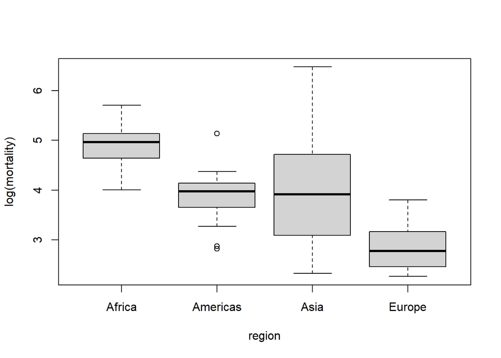

```r
infmort <- read.csv('infmort.csv')
infmort <- na.omit(infmort)
boxplot(log(mortality) ~ region, data = infmort)
```

### MLR

Update the model developed in in [C.2.6](https://nustat.github.io/STAT350-class-notes/Assignment%20C.html#section-15) by adding `region` as a predictor. Use this model to compute `adjusted_mortality` for each observation in the data, where adjusted mortality is the mortality after removing the estimated effect of `income`. Make a boxplot of log(`adjusted_mortality`) against `region`.

*(2 + 1 = 3 points)*

```r
income_region <- lm(log(mortality)~log(income)+region, data=infmort)
```

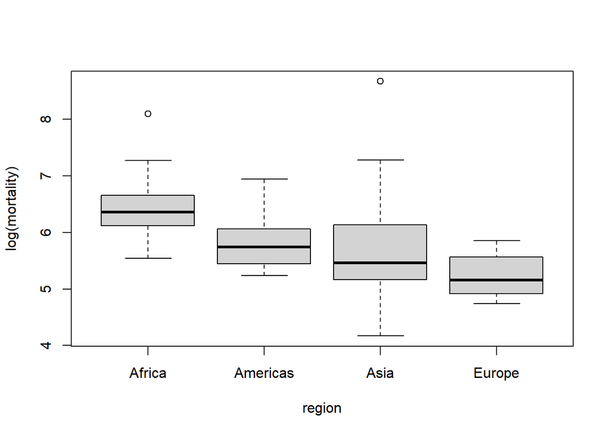

```r
adj_mortality <- exp(log(infmort['mortality']) - (-0.29939)*log(infmort['income']))
adj_mortality$region <- infmort$region
boxplot(log(mortality)~region, data = adj_mortality)
```

### Analysis

From the plot in the previous question ([E.2.2](https://nustat.github.io/STAT350-class-notes/Assignment%20E.html#mlr)):

1. Does Europe still seem to have the lowest mortality as compared to other regions after removing the effect of income from mortality?
2. After adjusting for income, is there any change in the mortality comparison among different regions. Compare the plot developed in the previous question ([E.2.2](https://nustat.github.io/STAT350-class-notes/Assignment%20E.html#mlr)) to the plot of `log(mortality)` against `region` developed earlier ([E.2.1](https://nustat.github.io/STAT350-class-notes/Assignment%20E.html#data-visualisation)) to answer this question.

**Hint:** Do any African / Asian / American countries seem to do better than all the European countries with regard to mortality after adjusting for income?

*(1 + 3 = 4 points)*

Europe does still seem to have the lowest average mortality rate after removing the effect of income, however the low end of mortality rates for countries in Asia is significantly lower than Europe now. Overall, while similar trends are seen in both of the plots, the median mortality rate for all 4 of the regions increased upon the removal of income’s effect on the model. The IQR sizes of each of the regions remained similar, but some outliers that were found in the second boxplot weren’t found in the first, and vice versa.

## GDP per capita

The dataset *soc_ind.csv* contains the GDP per capita of some countries along with several social indicators.

### Best predictor

For a simple linear regression model predicting `gdpPerCapita`, justify that `lifeFemale` (female life expectancy) will provide the best model fit *(ignore categorical predictors)*?

*(1 point)*

```r
library("dplyr")
GDP_data <- read.csv('soc_ind.csv')
cor(GDP_data$gdpPerCapita, (select_if(GDP_data, is.numeric)))
```

```
          Index economicActivityFemale economicActivityMale gdpPerCapita
[1,] 0.07367083             0.05296388           -0.1672306            1
     illiteracyFemale illiteracyMale infantMortality lifeFemale  lifeMale
[1,]       -0.4570117     -0.4716887      -0.5840601  0.6040285 0.5922666
```

We can see that `lifeFemale` has the highest correlation with `gdpPerCaptita`, based on the correlation coefficients above.

### Polynomial transformation

Develop a linear regression model to predict `gdpPerCapita` based on the appropriate polynomial transformation of `lifeFemale`. Find the appropriate polynomial transformation using the General Linear test approach. Support your choice of the appropriate polynomial transformation with a plot of the model on the data, showing the model fit.

*(3 + 2 = 5 points)*

```r
base_model <- lm(gdpPerCapita~lifeFemale, data=GDP_data)
more_complex <-lm(gdpPerCapita~lifeFemale+I(lifeFemale**2), data=GDP_data)
anova(base_model, more_complex)
```

```
Analysis of Variance Table

Model 1: gdpPerCapita ~ lifeFemale
Model 2: gdpPerCapita ~ lifeFemale + I(lifeFemale^2)
  Res.Df        RSS Df  Sum of Sq      F    Pr(>F)
1    153 5.3355e+10
2    152 4.2317e+10  1 1.1037e+10 39.645 3.109e-09 ***
---
Signif. codes:  0 '***' 0.001 '**' 0.01 '*' 0.05 '.' 0.1 ' ' 1
```

```r
base_model2 <- lm(gdpPerCapita~lifeFemale+I(lifeFemale**2), data=GDP_data)
more_complex2 <- lm(gdpPerCapita~lifeFemale+I(lifeFemale**2)+I(lifeFemale**3), data=GDP_data)
anova(base_model2, more_complex2)
```

```
Analysis of Variance Table

Model 1: gdpPerCapita ~ lifeFemale + I(lifeFemale^2)
Model 2: gdpPerCapita ~ lifeFemale + I(lifeFemale^2) + I(lifeFemale^3)
  Res.Df        RSS Df  Sum of Sq      F   Pr(>F)
1    152 4.2317e+10
2    151 4.0182e+10  1 2135128631 8.0235 0.005248 **
---
Signif. codes:  0 '***' 0.001 '**' 0.01 '*' 0.05 '.' 0.1 ' ' 1
```

```r
base_model3 <- lm(gdpPerCapita~lifeFemale+I(lifeFemale**2)+I(lifeFemale**3), data=GDP_data)
more_complex3 <- lm(gdpPerCapita~lifeFemale+I(lifeFemale**2)+I(lifeFemale**3)+I(lifeFemale**4), data=GDP_data)
anova(base_model3, more_complex3)
```

```
Analysis of Variance Table

Model 1: gdpPerCapita ~ lifeFemale + I(lifeFemale^2) + I(lifeFemale^3)
Model 2: gdpPerCapita ~ lifeFemale + I(lifeFemale^2) + I(lifeFemale^3) +
    I(lifeFemale^4)
  Res.Df        RSS Df Sum of Sq      F Pr(>F)
1    151 4.0182e+10
2    150 4.0181e+10  1   1047974 0.0039 0.9502
```

```r
base_model4 <- lm(gdpPerCapita~lifeFemale+I(lifeFemale**2)+I(lifeFemale**3)+I(lifeFemale**4), data=GDP_data)
more_complex4 <- lm(gdpPerCapita~lifeFemale+I(lifeFemale**2)+I(lifeFemale**3)+I(lifeFemale**4)+I(lifeFemale**5), data=GDP_data)
anova(base_model4, more_complex4)
```

```
Analysis of Variance Table

Model 1: gdpPerCapita ~ lifeFemale + I(lifeFemale^2) + I(lifeFemale^3) +
    I(lifeFemale^4)
Model 2: gdpPerCapita ~ lifeFemale + I(lifeFemale^2) + I(lifeFemale^3) +
    I(lifeFemale^4) + I(lifeFemale^5)
  Res.Df        RSS Df Sum of Sq      F Pr(>F)
1    150 4.0181e+10
2    149 3.9747e+10  1 434416792 1.6285 0.2039
```

When using the General Linear test approach, we find that doing the test with a 3rd order transformation vs. a 4th order transformation yields a very high p-value of 0.95, suggesting that a cubic transformation is suitable. Furthermore, when we test a 4th order vs. 5th order, we see that the p-value is less than the previous p-value.

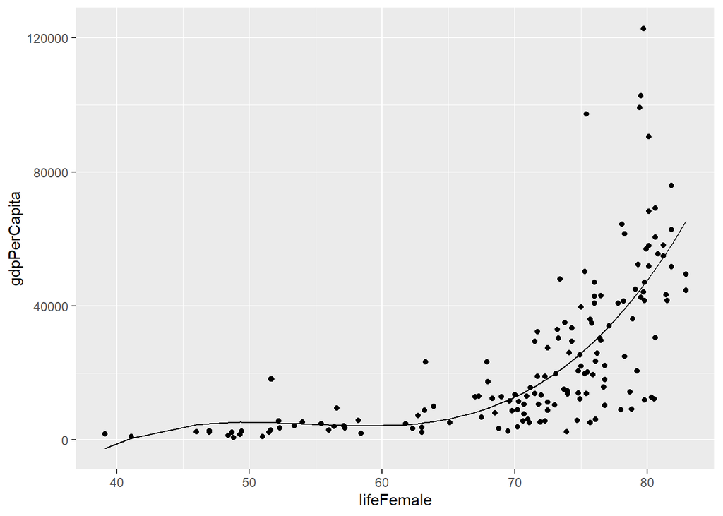

```r
ggplot(data = GDP_data, aes(x = lifeFemale, y = gdpPerCapita))+
  geom_point()+
  geom_line(aes(y = base_model3$fitted.values))
```

### VIF

Is there multicollinearity in the model? Find the VIF and comment.

*(2 points)*

```r
library(car)
vif(base_model3)
```

```
     lifeFemale I(lifeFemale^2) I(lifeFemale^3)
       8523.897       36065.747        9721.215
```

Yes, there seems to be very high amounts of multicollinearity. This makes sense though, as the model is polynomial.

### Centering

Center the predictor `lifeFemale` and re-develop the model. Did the severity of multicollinearity reduce in the updated model? If yes, what is the benefit of the reduced multicollinearity. Use the model summary of both the models as an evidence to support your arguments.

*(2 + 2 + 2 + 2 = 8 points)*

```r
GDP_data$lifeFemaleCentered <- GDP_data$lifeFemale - mean(GDP_data$lifeFemale)
cubic_centered <- lm(gdpPerCapita~lifeFemaleCentered+I(lifeFemaleCentered**2)+I(lifeFemaleCentered**3), data=GDP_data)
vif(cubic_centered)
```

```
     lifeFemaleCentered I(lifeFemaleCentered^2) I(lifeFemaleCentered^3)
               3.049211                8.097338               10.745614
```

### Interpretation

Develop a model to predict `gdpPerCapita` with `lifeFemale` and `continent` as predictors.

1. Interpret the intercept term.
2. For a given value of `lifeFemale`, are there any continents that **do not** have a significant difference between their mean `gdpPerCapita` and that of Africa? If yes, then which ones, and why? If no, then why not? Consider a significance level of 5%.

*(2 + 2 = 4 points)*

```r
GDP_lifeFemale_cont <- lm(gdpPerCapita~lifeFemale+continent, data=GDP_data)
summary(GDP_lifeFemale_cont)
```

```
Call:
lm(formula = gdpPerCapita ~ lifeFemale + continent, data = GDP_data)

Residuals:
   Min     1Q Median     3Q    Max
-35290  -9503  -2206   5890  74595

Coefficients:
                       Estimate Std. Error t value Pr(>|t|)
(Intercept)            -72077.3    11432.2  -6.305 3.14e-09 ***
lifeFemale               1393.4      194.1   7.180 3.14e-11 ***
continentAsia            1324.8     4805.1   0.276   0.7832
continentEurope          9167.0     5785.7   1.584   0.1152
continentNorth America -14457.3     5947.5  -2.431   0.0163 *
continentOceania       -14290.0     6063.8  -2.357   0.0198 *
continentSouth America -13286.9     6462.5  -2.056   0.0415 *
---
Signif. codes:  0 '***' 0.001 '**' 0.01 '*' 0.05 '.' 0.1 ' ' 1

Residual standard error: 16720 on 148 degrees of freedom
Multiple R-squared:  0.5076,    Adjusted R-squared:  0.4877
F-statistic: 25.43 on 6 and 148 DF,  p-value: < 2.2e-16
```

The intercept term represents the estimate of the mean of the “base case” of the reference group. In this instance, Africa is the base case. According the the p-values of each of the other continents, Europe and Asia do not have a significant difference between their mean gdpPerCapita and Africa’s mean gdp, as their p-values are greater than 0.05.

### Interaction

The model developed in the previous question has a limitation. It assumes that the increase in mean `gdpPerCapita` with a unit increase in `lifeFemale` does not depend on the `continent`.

1. Eliminate this limitation by including interaction of `continent` with `lifeFemale` in the model developed in the previous question ([E.3.5](https://nustat.github.io/STAT350-class-notes/Assignment%20E.html#interpretation-1)). Print the model summary of the model with interactions.
2. Interpret the coefficient of any one of the interaction terms.

*(1 + 2 = 3 points)*

```r
LF_cont_interaction <- lm(gdpPerCapita~lifeFemale*continent, data = GDP_data)
summary(LF_cont_interaction)
```

```
Call:
lm(formula = gdpPerCapita ~ lifeFemale * continent, data = GDP_data)

Residuals:
   Min     1Q Median     3Q    Max
-27376  -6337  -2217   5495  68805

Coefficients:
                                   Estimate Std. Error t value Pr(>|t|)
(Intercept)                        -17232.7    15265.7  -1.129   0.2609
lifeFemale                            428.6      264.2   1.622   0.1070
continentAsia                     -109409.3    26324.2  -4.156 5.55e-05 ***
continentEurope                   -277376.4    66280.2  -4.185 4.96e-05 ***
continentNorth America             -66002.2    48810.3  -1.352   0.1784
continentOceania                  -136731.8    57843.0  -2.364   0.0194 *
continentSouth America              -7830.3    81751.2  -0.096   0.9238
lifeFemale:continentAsia             1755.1      400.8   4.379 2.29e-05 ***
lifeFemale:continentEurope           3944.6      869.9   4.535 1.21e-05 ***
lifeFemale:continentNorth America     921.1      667.4   1.380   0.1697
lifeFemale:continentOceania          1898.4      812.8   2.336   0.0209 *
lifeFemale:continentSouth America     135.3     1134.4   0.119   0.9052
---
Signif. codes:  0 '***' 0.001 '**' 0.01 '*' 0.05 '.' 0.1 ' ' 1

Residual standard error: 15240 on 143 degrees of freedom
Multiple R-squared:  0.6049,    Adjusted R-squared:  0.5745
F-statistic:  19.9 on 11 and 143 DF,  p-value: < 2.2e-16
```

For a unit increase in lifeFemale, the increase in estimated mean GDP per capita of a country in Asia is 1755.1 greater than the increase in estimated mean GDP per capita of a country in Africa.

**Note: Use the model developed in this question ([E.3.6](https://nustat.github.io/STAT350-class-notes/Assignment%20E.html#interaction)) for all the questions below.**

### Model visualisation

Use the model developed in ([E.3.6](https://nustat.github.io/STAT350-class-notes/Assignment%20E.html#interaction)) to plot regression lines for Africa, Asia, and Europe. Put `gdpPerCapita` on the vertical axis and `lifeFemale` on the horizontal axis. Use a legend to distinguish among the regression lines of the three continents.

*(3 points)*

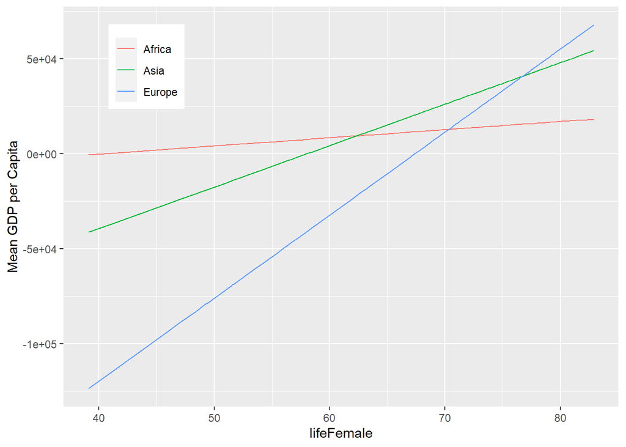

```r
colors <- c("Africa" = "red", "Asia" = "blue", "Europe" = "green")

coefs <- LF_cont_interaction$coefficients
x <- GDP_data$lifeFemale
ggplot(data = GDP_data, aes(x = lifeFemale))+
  geom_line(aes(y = coefs['(Intercept)']+x*coefs['lifeFemale'], color = 'Africa'))+
  geom_line(aes(y = coefs['(Intercept)']+x*coefs['lifeFemale']+coefs['continentAsia']+x*coefs['lifeFemale:continentAsia'], color = 'Asia'))+
  geom_line(aes(y = coefs['(Intercept)']+x*coefs['lifeFemale']+coefs['continentEurope']+x*coefs['lifeFemale:continentEurope'], color = 'Europe'))+
  theme(legend.title = element_blank(),
        legend.position = c(0.15,0.85))+
  labs(
    y = 'Mean GDP per Capita',
    x = 'lifeFemale'
  )
```

### Analysing the model

Based on the plot develop in the previous question ([E.3.7](https://nustat.github.io/STAT350-class-notes/Assignment%20E.html#model-visualisation)), which continent has the highest increase in mean `gdpPerCapita` for a unit increase in `lifeFemale`, and which one has the least? Justify your answer.

*(1 + 1 + 2 = 4 points)*

For a unit increase in lifeFemale, Europe sees the highest increase in gdpPerCapita, as its slope is the steepest. On the other hand, Africa sees the lowest increase in gdpPerCapita per unit increase in lifeFemale, as its slope is the flattest.

### Quantifying difference in slope

On an average, how much higher is the increase in GDP per Capita of a European country than increase in GDP per Capita of an Asian country for an increase of 1 year in female life expectancy?

*(2 points)*

$PE = \hat{\beta_9}-\hat{\beta_8} = 3944.6 - 1755.1 = 2189.5$

### Quantifying uncertainty of difference in slope

Find the 95% confidence interval of the metric obtained in the previous question.

In other words, find the 95% confidence interval of the difference of increase in GDP per Capita of a European country and increase in GDP per Capita of an Asian country, for an increase of 1 year in female life expectancy.

*Note: You may use the R function `vcov()` to find the variance-covariance matrix of the regression coefficients:*

$Var(\hat{\beta}) = \sigma^2(X^TX)^{-1}$

*(5 points)*

See attachments for my work showing the resulting equation: $var(PE) = var(\hat{\beta_9})+var(\hat{\beta_8})-2cov(\hat{\beta_9},\hat{\beta_8})$

```r
vcov_matrix <- vcov(LF_cont_interaction)
variance_point_estimate = vcov_matrix[9,9] + vcov_matrix[8,8] - 2*vcov_matrix[9,8]

# Standard deviation of the point estimate
# df = 155 obs - 12 params = 143
std_point_estimate = sqrt(variance_point_estimate)

# Upper bound of the 95% CI of the point estimate
UB <- 2189.5 + std_point_estimate*qt(0.975, 143)
print(paste0("Upper bound = ",UB))
```

```
[1] "Upper bound = 3932.76067240979"
```

```r
LB <- 2189.5 - std_point_estimate*qt(0.975, 143)
print(paste0("Lower bound = ", LB))
```

```
[1] "Lower bound = 446.239327590214"
```

The 95% confidence interval is: [446.239,3932.761].